# Brix Analysis

Steven D. Rowland

Tuesday, November 25, 2014

======================================= Data Import and Seperation

```r
#Data Import and Seperation
comb.data=read.csv("All Combined.csv",header=T)
comb.data$Obs=factor(comb.data$Obs)
# comb.data$Obs=as.factor(comb.data$Obs)

#Subset
data.sub.a=comb.data[which(comb.data$Block=="A"),]
data.sub.b=comb.data[which(comb.data$Block=="B"),]
data.sub.c=comb.data[which(comb.data$Block=="C"),]
data.sub.d=comb.data[which(comb.data$Block=="D"),]
```

This is somewhat irrelevant now except for block A seperation but left it in for now.

======================================  
**ILs & BILs**

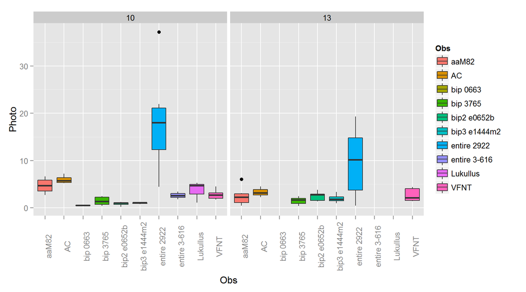

```r
plot.summary=function(x) {
  x=na.omit(x)
  y=mean(x)
  sem=sd(x)/sqrt(length(x))
  return(data.frame(
    y=y,
    ymin=y-sem,
    ymax=y+sem
    ))} ## I borrowed your function Julin, I hope this okay. Seemed easier than rewriting it myself.

## BOXPLOTS
ggplot(data.sub.a,aes(Obs,Photo,fill=Obs))+geom_boxplot()+facet_wrap(~Weeks)+theme(axis.text.x=element_text(angle=90))
```

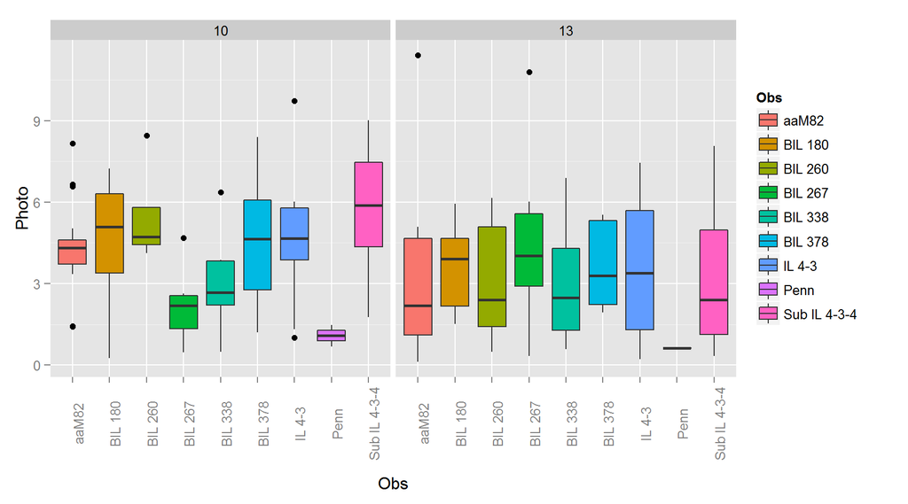

```r
ggplot(data.sub.b,aes(Obs,Photo,fill=Obs))+geom_boxplot()+facet_wrap(~Weeks)+theme(axis.text.x=element_text(angle=90))
```

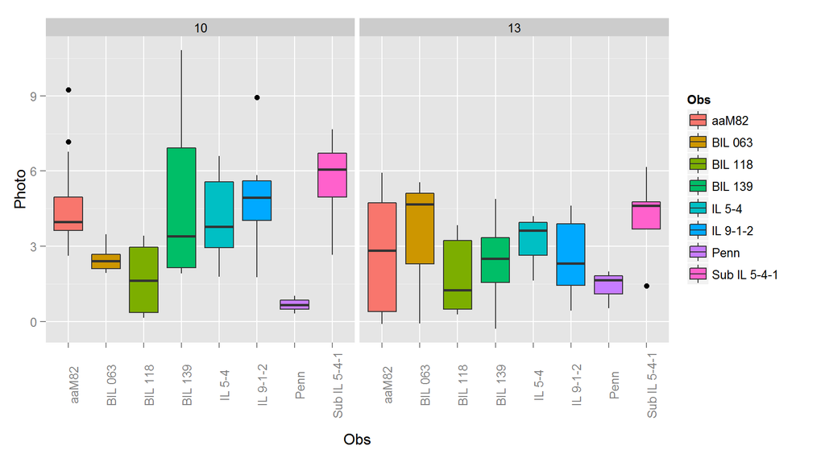

```r
ggplot(data.sub.c,aes(Obs,Photo,fill=Obs))+geom_boxplot()+facet_wrap(~Weeks)+theme(axis.text.x=element_text(angle=90))
```

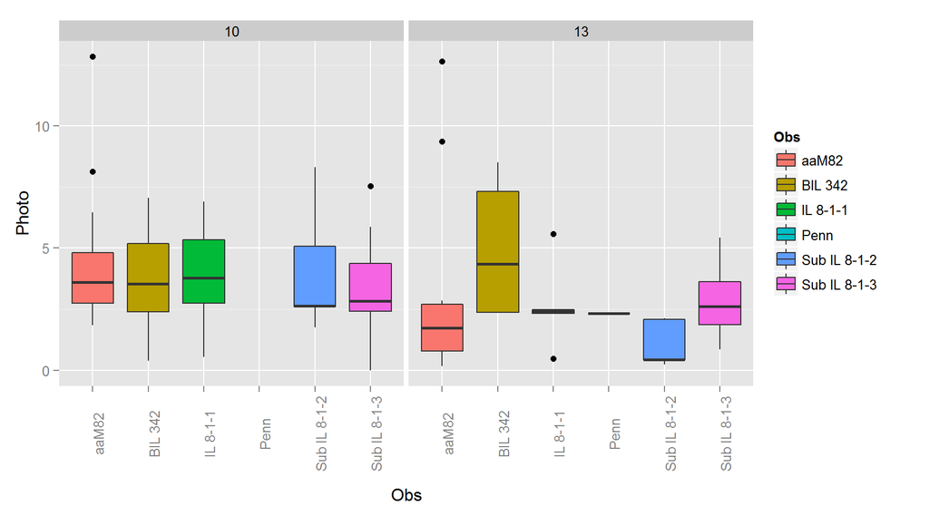

```r
ggplot(data.sub.d,aes(Obs,Photo,fill=Obs))+geom_boxplot()+facet_wrap(~Weeks)+theme(axis.text.x=element_text(angle=90))
```

```r
##
```

Individual block boxplots don’t look promising.

# **BLOCKS B,C,D**

*Combining Blocks B,C and D*

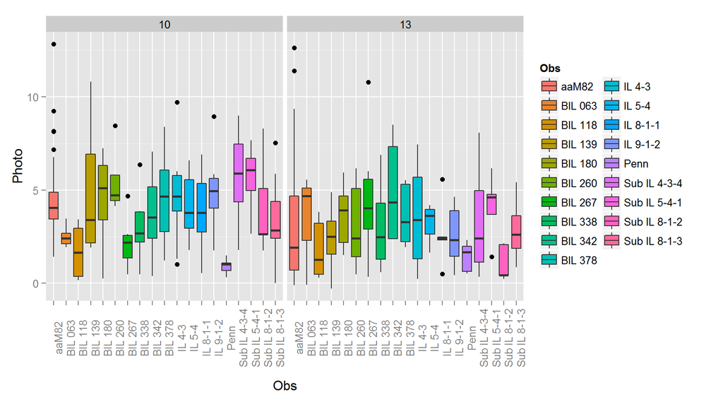

```r
## COMBINED BLOCKS PLOT
list=c("B","C","D")
testset=droplevels(comb.data[comb.data$Block %in% list,])
# testset=testset[testset$Weeks==13,]
# levels(testset$Obs)
ggplot(testset,aes(Obs,Photo,fill=Obs))+geom_boxplot()+theme(axis.text.x=element_text(angle=90))+facet_wrap(~Weeks)+guides(fill=guide_legend(ncol=2)) # This is rather messy.
```

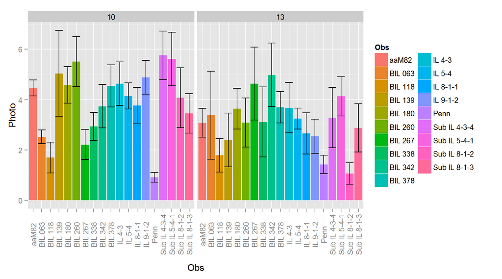

```r
ggplot(testset,aes(Obs,Photo,fill=Obs))+stat_summary(fun.data=plot.summary,geom="bar")+stat_summary(fun.data=plot.summary,geom="errorbar")+facet_wrap(~ Weeks)+theme(axis.text.x  = element_text(angle=90, vjust=0.5))+guides(fill=guide_legend(ncol=2))#+stat_smooth(method="lm",se=F)
```

This looks rather promising now with adjusted Photo values to per leaflet. BIL063, 118, 267, 338 and Penn are all down.

```r
## MODELS
bdc=lmer(Photo~Obs+VpdA+(1|Row)+(1|Col)+(1|Date)+(1|Weeks),data=testset)
summary(bdc)
```

```
## Linear mixed model fit by REML t-tests use Satterthwaite approximations
##   to degrees of freedom [merModLmerTest]
## Formula: Photo ~ Obs + VpdA + (1 | Row) + (1 | Col) + (1 | Date) + (1 |
##     Weeks)
##    Data: testset
##
## REML criterion at convergence: 1250.7
##
## Scaled residuals:
##     Min      1Q  Median      3Q     Max
## -2.2019 -0.6263 -0.1220  0.5706  4.1182
##
## Random effects:
##  Groups   Name        Variance Std.Dev.
##  Col      (Intercept) 0.16500  0.4062
##  Date     (Intercept) 0.04824  0.2196
##  Row      (Intercept) 0.00000  0.0000
##  Weeks    (Intercept) 0.03188  0.1785
##  Residual             3.95753  1.9894
## Number of obs: 301, groups:  Col, 57; Date, 6; Row, 5; Weeks, 2
##
## Fixed effects:
##                  Estimate Std. Error        df t value Pr(>|t|)
## (Intercept)      10.37853    0.72846  49.00000  14.247  < 2e-16 ***
## ObsBIL 063       -0.53016    0.75719 276.69000  -0.700  0.48441
## ObsBIL 118       -1.16636    0.64274 264.53000  -1.815  0.07071 .
## ObsBIL 139        0.09290    0.71637 279.43000   0.130  0.89692
## ObsBIL 180       -0.53644    0.60702 247.21000  -0.884  0.37771
## ObsBIL 260       -0.04890    0.68989 272.84000  -0.071  0.94354
## ObsBIL 267       -1.54655    0.64504 267.22000  -2.398  0.01719 *
## ObsBIL 338       -1.71231    0.62773 244.72000  -2.728  0.00684 **
## ObsBIL 342        0.75983    0.63677 269.99000   1.193  0.23382
## ObsBIL 378       -0.58448    0.58965 239.58000  -0.991  0.32257
## ObsIL 4-3        -0.69258    0.55895 275.93000  -1.239  0.21637
## ObsIL 5-4         0.18905    0.56079 273.80000   0.337  0.73629
## ObsIL 8-1-1      -0.06175    0.60199 246.32000  -0.103  0.91838
## ObsIL 9-1-2       0.15740    0.57800 261.35000   0.272  0.78559
## ObsPenn          -2.20400    0.68525 278.55000  -3.216  0.00145 **
## ObsSub IL 4-3-4  -0.23117    0.60281 259.67000  -0.383  0.70168
## ObsSub IL 5-4-1   0.66545    0.72156 265.80000   0.922  0.35725
```

[output cut: 52 more lines]

```
## ObsBIL 260
## ObsBIL 267
## ObsBIL 338
## ObsBIL 342
## ObsBIL 378
## ObsIL 4-3
## ObsIL 5-4
## ObsIL 8-1-1
## ObsIL 9-1-2
## ObsPenn
## ObsSIL4-3-4
## ObsSIL5-4-1
## ObsSIL8-1-2
## ObsSIL8-1-3  0.142
## VpdA        -0.094    -0.068
```

```r
drop1(bdc)# Suggests that dropping VpdA makes the model worse.
```

```
## Single term deletions
##
## Model:
## Photo ~ Obs + VpdA + (1 | Row) + (1 | Col) + (1 | Date) + (1 |
##     Weeks)
##        Df    AIC
## <none>    1312.2
## Obs    18 1307.6
## VpdA    1 1394.8
```

```r
bdc2=lmer(Photo~Obs+VpdA+(1|Col)+(1|Date)+(1|Weeks),data=testset)
anova(bdc,bdc2) #Keeping simpler model.
```

```
## refitting model(s) with ML (instead of REML)
```

```
## Data: testset
## Models:
## ..1: Photo ~ Obs + VpdA + (1 | Col) + (1 | Date) + (1 | Weeks)
## object: Photo ~ Obs + VpdA + (1 | Row) + (1 | Col) + (1 | Date) + (1 |
## object:     Weeks)
##        Df    AIC    BIC  logLik deviance Chisq Chi Df Pr(>Chisq)
## ..1    24 1310.2 1399.1 -631.07   1262.2
## object 25 1312.2 1404.8 -631.07   1262.2     0      1          1
```

```r
summary(bdc2)
```

```
## Linear mixed model fit by REML t-tests use Satterthwaite approximations
##   to degrees of freedom [merModLmerTest]
## Formula: Photo ~ Obs + VpdA + (1 | Col) + (1 | Date) + (1 | Weeks)
##    Data: testset
##
## REML criterion at convergence: 1250.7
##
## Scaled residuals:
##     Min      1Q  Median      3Q     Max
## -2.2019 -0.6263 -0.1220  0.5706  4.1182
##
## Random effects:
##  Groups   Name        Variance Std.Dev.
##  Col      (Intercept) 0.16500  0.4062
##  Date     (Intercept) 0.04824  0.2196
##  Weeks    (Intercept) 0.03188  0.1785
##  Residual             3.95753  1.9894
## Number of obs: 301, groups:  Col, 57; Date, 6; Weeks, 2
##
## Fixed effects:
##                  Estimate Std. Error        df t value Pr(>|t|)
## (Intercept)      10.37853    0.72846  49.00000  14.247  < 2e-16 ***
## ObsBIL 063       -0.53016    0.75719 276.69000  -0.700  0.48441
## ObsBIL 118       -1.16636    0.64274 264.53000  -1.815  0.07071 .
## ObsBIL 139        0.09290    0.71637 279.43000   0.130  0.89692
## ObsBIL 180       -0.53644    0.60702 247.21000  -0.884  0.37771
## ObsBIL 260       -0.04890    0.68989 272.84000  -0.071  0.94354
## ObsBIL 267       -1.54655    0.64504 267.22000  -2.398  0.01719 *
## ObsBIL 338       -1.71231    0.62773 244.72000  -2.728  0.00684 **
## ObsBIL 342        0.75983    0.63677 269.99000   1.193  0.23382
## ObsBIL 378       -0.58448    0.58965 239.58000  -0.991  0.32257
## ObsIL 4-3        -0.69258    0.55895 275.93000  -1.239  0.21637
## ObsIL 5-4         0.18905    0.56079 273.80000   0.337  0.73629
## ObsIL 8-1-1      -0.06175    0.60199 246.32000  -0.103  0.91838
## ObsIL 9-1-2       0.15740    0.57800 261.35000   0.272  0.78559
## ObsPenn          -2.20400    0.68525 278.55000  -3.216  0.00145 **
## ObsSub IL 4-3-4  -0.23117    0.60281 259.67000  -0.383  0.70168
## ObsSub IL 5-4-1   0.66545    0.72156 265.80000   0.922  0.35725
## ObsSub IL 8-1-2  -0.57443    0.68711 279.42000  -0.836  0.40387
## ObsSub IL 8-1-3  -0.18577    0.62084 241.04000  -0.299  0.76503
```

[output cut: 50 more lines]

```
## ObsBIL 260
## ObsBIL 267
## ObsBIL 338
## ObsBIL 342
## ObsBIL 378
## ObsIL 4-3
## ObsIL 5-4
## ObsIL 8-1-1
## ObsIL 9-1-2
## ObsPenn
## ObsSIL4-3-4
## ObsSIL5-4-1
## ObsSIL8-1-2
## ObsSIL8-1-3  0.142
## VpdA        -0.094    -0.068
```

```r
drop1(bdc2)
```

```
## Single term deletions
##
## Model:
## Photo ~ Obs + VpdA + (1 | Col) + (1 | Date) + (1 | Weeks)
##        Df    AIC
## <none>    1310.2
## Obs    18 1305.6
## VpdA    1 1392.8
```

```r
bdc3=lmer(Photo~Obs+VpdA+(1|Col)+(1|Date),data=testset)
anova(bdc2,bdc3)
```

```
## refitting model(s) with ML (instead of REML)
```

```
## Data: testset
## Models:
## ..1: Photo ~ Obs + VpdA + (1 | Col) + (1 | Date)
## object: Photo ~ Obs + VpdA + (1 | Col) + (1 | Date) + (1 | Weeks)
##        Df    AIC    BIC  logLik deviance Chisq Chi Df Pr(>Chisq)
## ..1    23 1308.2 1393.4 -631.07   1262.2
## object 24 1310.2 1399.1 -631.07   1262.2     0      1          1
```

```r
summary(bdc3)
```

```
## Linear mixed model fit by REML t-tests use Satterthwaite approximations
##   to degrees of freedom [merModLmerTest]
## Formula: Photo ~ Obs + VpdA + (1 | Col) + (1 | Date)
##    Data: testset
##
## REML criterion at convergence: 1250.9
##
## Scaled residuals:
##     Min      1Q  Median      3Q     Max
## -2.2068 -0.6296 -0.1315  0.5720  4.1355
##
## Random effects:
##  Groups   Name        Variance Std.Dev.
##  Col      (Intercept) 0.16448  0.4056
##  Date     (Intercept) 0.06873  0.2622
##  Residual             3.95776  1.9894
## Number of obs: 301, groups:  Col, 57; Date, 6
##
## Fixed effects:
##                  Estimate Std. Error        df t value Pr(>|t|)
## (Intercept)      10.48032    0.72297  65.51000  14.496  < 2e-16 ***
## ObsBIL 063       -0.51920    0.75723 276.81000  -0.686  0.49350
## ObsBIL 118       -1.15404    0.64314 264.74000  -1.794  0.07389 .
## ObsBIL 139        0.08411    0.71672 279.35000   0.117  0.90666
## ObsBIL 180       -0.54491    0.60758 248.17000  -0.897  0.37067
## ObsBIL 260       -0.08704    0.69021 273.05000  -0.126  0.89974
## ObsBIL 267       -1.56759    0.64490 267.44000  -2.431  0.01572 *
## ObsBIL 338       -1.70774    0.62866 247.94000  -2.716  0.00706 **
## ObsBIL 342        0.75946    0.63719 270.60000   1.192  0.23435
## ObsBIL 378       -0.60541    0.58975 239.52000  -1.027  0.30567
## ObsIL 4-3        -0.70367    0.55916 276.49000  -1.258  0.20930
## ObsIL 5-4         0.20115    0.56106 273.94000   0.359  0.72023
## ObsIL 8-1-1      -0.05571    0.60210 246.00000  -0.093  0.92636
## ObsIL 9-1-2       0.16040    0.57818 261.21000   0.277  0.78167
## ObsPenn          -2.20447    0.68550 278.52000  -3.216  0.00145 **
## ObsSub IL 4-3-4  -0.25530    0.60280 259.51000  -0.424  0.67226
## ObsSub IL 5-4-1   0.64390    0.72137 266.12000   0.893  0.37287
## ObsSub IL 8-1-2  -0.57435    0.68762 279.87000  -0.835  0.40428
## ObsSub IL 8-1-3  -0.17662    0.62110 241.19000  -0.284  0.77637
## VpdA             -1.80358    0.18267  93.42000  -9.874 4.44e-16 ***
```

[output cut: 49 more lines]

```
## ObsBIL 260
## ObsBIL 267
## ObsBIL 338
## ObsBIL 342
## ObsBIL 378
## ObsIL 4-3
## ObsIL 5-4
## ObsIL 8-1-1
## ObsIL 9-1-2
## ObsPenn
## ObsSIL4-3-4
## ObsSIL5-4-1
## ObsSIL8-1-2
## ObsSIL8-1-3  0.143
## VpdA        -0.096    -0.062
```

```r
bdc4=lmer(Photo~Obs+VpdA+(1|Col),data=testset)
anova(bdc3,bdc4) # Simpilest Model, and best based on AIC.
```

```
## refitting model(s) with ML (instead of REML)
```

```
## Data: testset
## Models:
## ..1: Photo ~ Obs + VpdA + (1 | Col)
## object: Photo ~ Obs + VpdA + (1 | Col) + (1 | Date)
##        Df    AIC    BIC  logLik deviance  Chisq Chi Df Pr(>Chisq)
## ..1    22 1306.4 1388.0 -631.22   1262.4
## object 23 1308.2 1393.4 -631.07   1262.2 0.2901      1     0.5902
```

```r
summary(bdc4)
```

```
## Linear mixed model fit by REML t-tests use Satterthwaite approximations
##   to degrees of freedom [merModLmerTest]
## Formula: Photo ~ Obs + VpdA + (1 | Col)
##    Data: testset
##
## REML criterion at convergence: 1251.7
##
## Scaled residuals:
##     Min      1Q  Median      3Q     Max
## -2.1116 -0.6497 -0.1306  0.5611  4.1841
##
## Random effects:
##  Groups   Name        Variance Std.Dev.
##  Col      (Intercept) 0.151    0.3886
##  Residual             4.020    2.0049
## Number of obs: 301, groups:  Col, 57
##
## Fixed effects:
##                   Estimate Std. Error         df t value Pr(>|t|)
## (Intercept)      1.040e+01  6.714e-01  2.771e+02  15.487  < 2e-16 ***
## ObsBIL 063      -5.218e-01  7.612e-01  2.802e+02  -0.686  0.49355
## ObsBIL 118      -1.211e+00  6.446e-01  2.643e+02  -1.878  0.06146 .
## ObsBIL 139       1.006e-01  7.190e-01  2.808e+02   0.140  0.88886
## ObsBIL 180      -5.518e-01  6.071e-01  2.451e+02  -0.909  0.36430
## ObsBIL 260      -2.665e-02  6.893e-01  2.736e+02  -0.039  0.96919
## ObsBIL 267      -1.576e+00  6.461e-01  2.660e+02  -2.440  0.01535 *
## ObsBIL 338      -1.759e+00  6.263e-01  2.435e+02  -2.808  0.00538 **
## ObsBIL 342       8.014e-01  6.383e-01  2.690e+02   1.256  0.21034
## ObsBIL 378      -5.980e-01  5.900e-01  2.378e+02  -1.013  0.31186
## ObsIL 4-3       -7.576e-01  5.584e-01  2.752e+02  -1.357  0.17601
## ObsIL 5-4        1.655e-01  5.627e-01  2.748e+02   0.294  0.76893
## ObsIL 8-1-1      7.409e-04  6.030e-01  2.453e+02   0.001  0.99902
## ObsIL 9-1-2      1.619e-01  5.803e-01  2.628e+02   0.279  0.78049
## ObsPenn         -2.226e+00  6.882e-01  2.804e+02  -3.234  0.00137 **
## ObsSub IL 4-3-4 -2.293e-01  6.037e-01  2.584e+02  -0.380  0.70444
## ObsSub IL 5-4-1  6.487e-01  7.241e-01  2.673e+02   0.896  0.37116
## ObsSub IL 8-1-2 -5.863e-01  6.893e-01  2.800e+02  -0.851  0.39570
## ObsSub IL 8-1-3 -1.299e-01  6.207e-01  2.401e+02  -0.209  0.83435
## VpdA            -1.781e+00  1.718e-01  2.663e+02 -10.365  < 2e-16 ***
## ---
```

[output cut: 48 more lines]

```
## ObsBIL 260
## ObsBIL 267
## ObsBIL 338
## ObsBIL 342
## ObsBIL 378
## ObsIL 4-3
## ObsIL 5-4
## ObsIL 8-1-1
## ObsIL 9-1-2
## ObsPenn
## ObsSIL4-3-4
## ObsSIL5-4-1
## ObsSIL8-1-2
## ObsSIL8-1-3  0.139
## VpdA        -0.090    -0.066
```

This model says BIL267, 338 and Penn are sig. different and 118 is close.

```r
drop1(bdc4) # VpdA is good. I'm just ignoring its Obs output.
```

```
## Single term deletions
##
## Model:
## Photo ~ Obs + VpdA + (1 | Col)
##        Df    AIC
## <none>    1306.4
## Obs    18 1303.4
## VpdA    1 1400.1
```

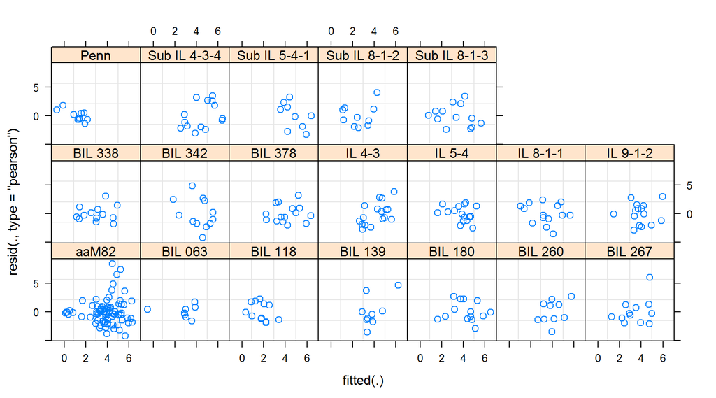

```r
##

## PLOTS
plot(bdc4,resid(.,type="pearson")~fitted(.)|Obs) # No distinct patterns.
```

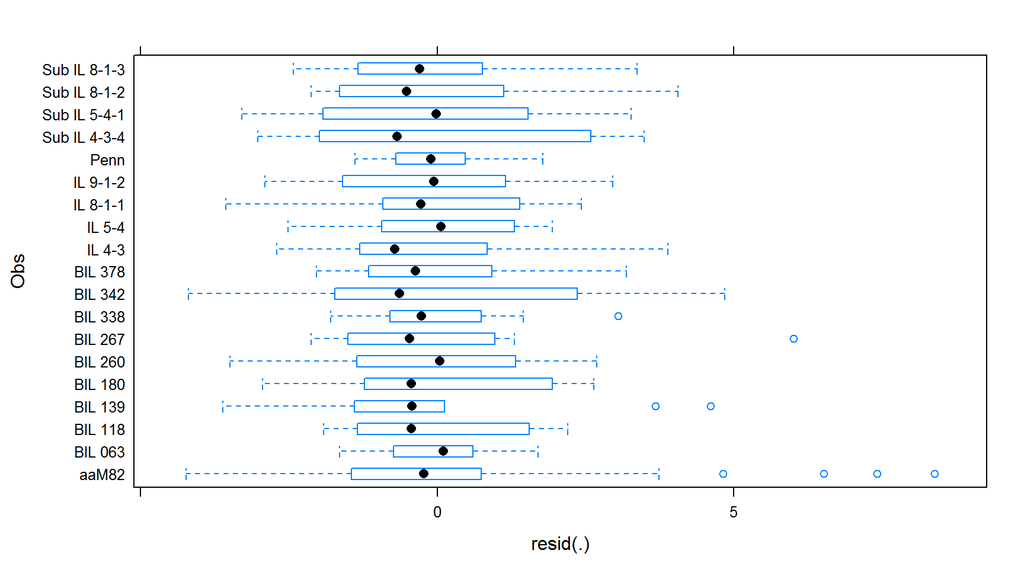

```r
plot(bdc4, Obs~resid(.))
```

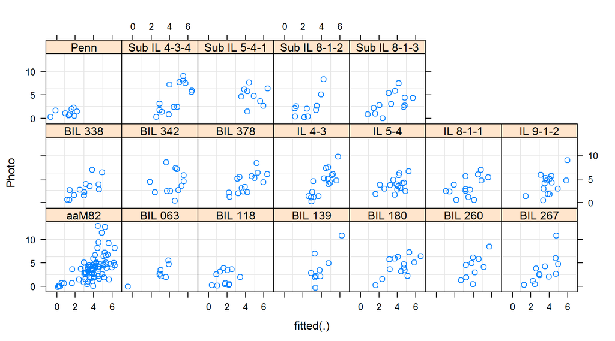

```r
plot(bdc4, Photo~fitted(.)|Obs)
```

Use bdc4 for prediction.

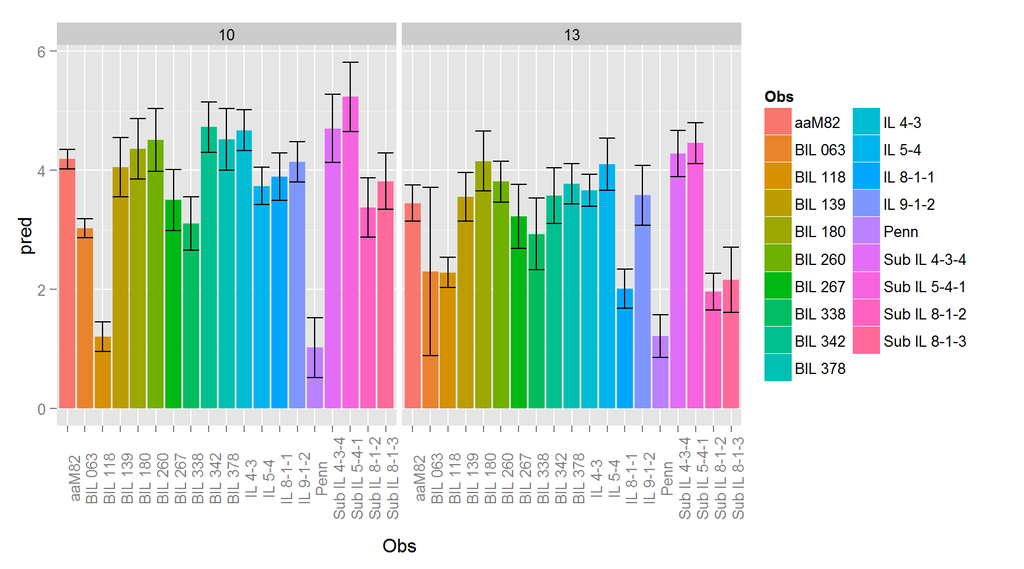

```r
testset$pred=predict(bdc4,re.form=NA)
ggplot(testset,aes(Obs,pred,fill=Obs))+stat_summary(fun.data=plot.summary,geom="bar")+stat_summary(fun.data=plot.summary,geom="errorbar")+theme(axis.text.x=element_text(angle=90))+facet_wrap(~Weeks)+guides(fill=guide_legend(ncol=2))
```

```r
##
```

VPD vs Photo plots for each line with VPD binned at 0.5

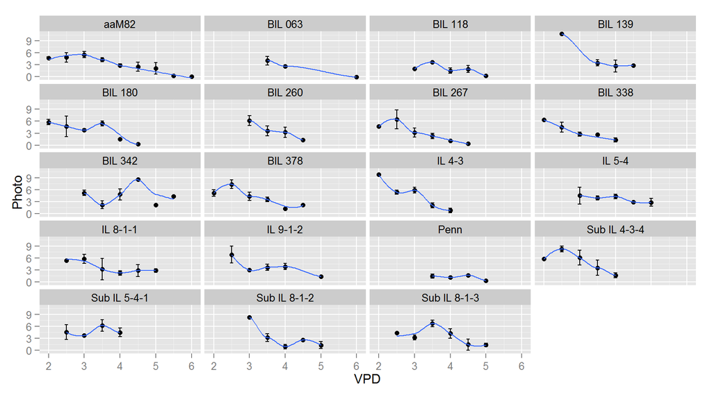

```r
ggplot(testset,aes(round_any(VpdA,0.5),Photo))+stat_summary(fun.data=plot.summary,geom="point")+stat_summary(fun.data=plot.summary,geom="errorbar",width=0.1)+guides(colour=guide_legend(ncol=2))+facet_wrap(~Obs,ncol=4)+stat_smooth(method="loess",se=F)+xlab("VPD")
```

Testing residuals. Taken essentially from Julin’s script.

```r
## RESIDUALS
lmtest=lm(Photo~VpdA,data=testset)
summary(lmtest)
```

```
##
## Call:
## lm(formula = Photo ~ VpdA, data = testset)
##
## Residuals:
##     Min      1Q  Median      3Q     Max
## -3.9449 -1.5384 -0.1125  1.1573  9.2881
##
## Coefficients:
##             Estimate Std. Error t value Pr(>|t|)
## (Intercept)   9.6262     0.5854   16.45   <2e-16 ***
## VpdA         -1.6593     0.1592  -10.43   <2e-16 ***
## ---
## Signif. codes:  0 '***' 0.001 '**' 0.01 '*' 0.05 '.' 0.1 ' ' 1
##
## Residual standard error: 2.093 on 299 degrees of freedom
## Multiple R-squared:  0.2666, Adjusted R-squared:  0.2641
## F-statistic: 108.7 on 1 and 299 DF,  p-value: < 2.2e-16
```

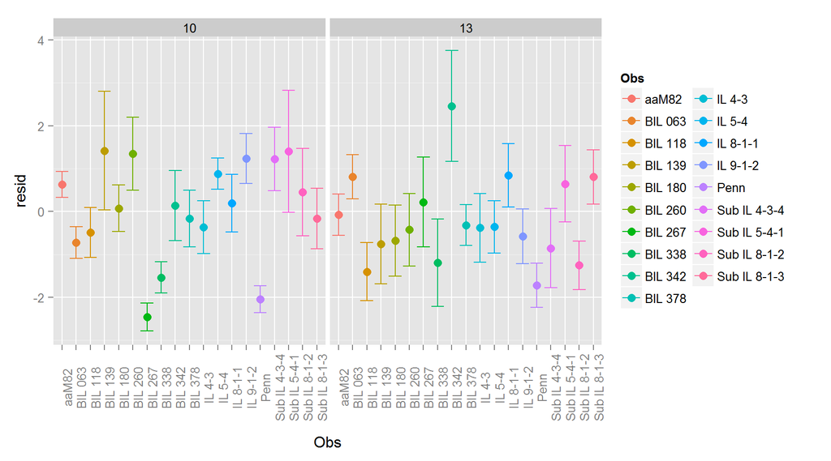

```r
testset$resid=residuals(lmtest)

ggplot(testset,aes(Obs,resid,colour=Obs))+stat_summary(fun.data=plot.summary,geom="point",size=3)+stat_summary(fun.data=plot.summary,geom="errorbar")+theme(axis.text.x=element_text(angle=90))+guides(colour=guide_legend(ncol=2))+facet_wrap(~Weeks)
```

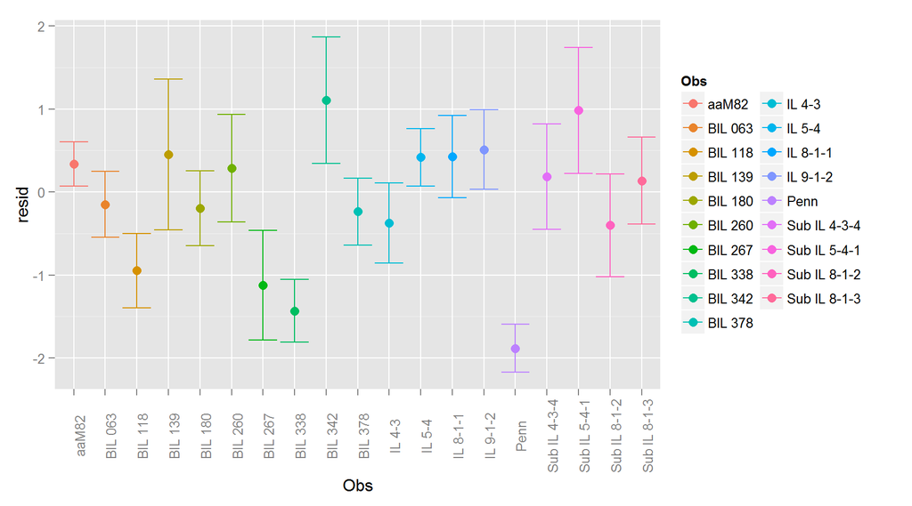

```r
ggplot(testset,aes(Obs,resid,colour=Obs))+stat_summary(fun.data=plot.summary,geom="point",size=3)+stat_summary(fun.data=plot.summary,geom="errorbar")+theme(axis.text.x=element_text(angle=90))+guides(colour=guide_legend(ncol=2))
```

```r
##
```

```r
bdc5=lmer(resid~Obs+VpdA+(1|Row)+(1|Col)+(1|Date)+(1|Weeks),data=testset)
summary(bdc5)
```

```
## Linear mixed model fit by REML t-tests use Satterthwaite approximations
##   to degrees of freedom [merModLmerTest]
## Formula: resid ~ Obs + VpdA + (1 | Row) + (1 | Col) + (1 | Date) + (1 |
##     Weeks)
##    Data: testset
##
## REML criterion at convergence: 1250.7
##
## Scaled residuals:
##     Min      1Q  Median      3Q     Max
## -2.2019 -0.6263 -0.1220  0.5706  4.1182
##
## Random effects:
##  Groups   Name        Variance Std.Dev.
##  Col      (Intercept) 0.16500  0.4062
##  Date     (Intercept) 0.04824  0.2196
##  Row      (Intercept) 0.00000  0.0000
##  Weeks    (Intercept) 0.03188  0.1785
##  Residual             3.95753  1.9894
## Number of obs: 301, groups:  Col, 57; Date, 6; Row, 5; Weeks, 2
##
## Fixed effects:
##                  Estimate Std. Error        df t value Pr(>|t|)
## (Intercept)       0.75237    0.72846  49.00000   1.033  0.30676
## ObsBIL 063       -0.53016    0.75719 276.69000  -0.700  0.48441
## ObsBIL 118       -1.16636    0.64274 264.53000  -1.815  0.07071 .
## ObsBIL 139        0.09290    0.71637 279.43000   0.130  0.89692
## ObsBIL 180       -0.53644    0.60702 247.21000  -0.884  0.37771
## ObsBIL 260       -0.04890    0.68989 272.84000  -0.071  0.94354
## ObsBIL 267       -1.54655    0.64504 267.22000  -2.398  0.01719 *
## ObsBIL 338       -1.71231    0.62773 244.72000  -2.728  0.00684 **
## ObsBIL 342        0.75983    0.63677 269.99000   1.193  0.23382
## ObsBIL 378       -0.58448    0.58965 239.58000  -0.991  0.32257
## ObsIL 4-3        -0.69258    0.55895 275.93000  -1.239  0.21637
## ObsIL 5-4         0.18905    0.56079 273.80000   0.337  0.73629
## ObsIL 8-1-1      -0.06175    0.60199 246.32000  -0.103  0.91838
## ObsIL 9-1-2       0.15740    0.57800 261.35000   0.272  0.78559
## ObsPenn          -2.20400    0.68525 278.55000  -3.216  0.00145 **
## ObsSub IL 4-3-4  -0.23117    0.60281 259.67000  -0.383  0.70168
## ObsSub IL 5-4-1   0.66545    0.72156 265.80000   0.922  0.35725
```

[output cut: 52 more lines]

```
## ObsBIL 260
## ObsBIL 267
## ObsBIL 338
## ObsBIL 342
## ObsBIL 378
## ObsIL 4-3
## ObsIL 5-4
## ObsIL 8-1-1
## ObsIL 9-1-2
## ObsPenn
## ObsSIL4-3-4
## ObsSIL5-4-1
## ObsSIL8-1-2
## ObsSIL8-1-3  0.142
## VpdA        -0.094    -0.068
```

```r
bdc6=lmer(resid~Obs+VpdA+(1|Row)+(1|Col)+(1|Weeks),data=testset)
anova(bdc5,bdc6)
```

```
## refitting model(s) with ML (instead of REML)
```

```
## Data: testset
## Models:
## ..1: resid ~ Obs + VpdA + (1 | Row) + (1 | Col) + (1 | Weeks)
## object: resid ~ Obs + VpdA + (1 | Row) + (1 | Col) + (1 | Date) + (1 |
## object:     Weeks)
##        Df    AIC    BIC  logLik deviance  Chisq Chi Df Pr(>Chisq)
## ..1    24 1310.4 1399.3 -631.19   1262.4
## object 25 1312.2 1404.8 -631.07   1262.2 0.2359      1     0.6272
```

```r
summary(bdc6)
```

```
## Linear mixed model fit by REML t-tests use Satterthwaite approximations
##   to degrees of freedom [merModLmerTest]
## Formula: resid ~ Obs + VpdA + (1 | Row) + (1 | Col) + (1 | Weeks)
##    Data: testset
##
## REML criterion at convergence: 1251.1
##
## Scaled residuals:
##     Min      1Q  Median      3Q     Max
## -2.1400 -0.6350 -0.1230  0.5722  4.1311
##
## Random effects:
##  Groups   Name        Variance Std.Dev.
##  Col      (Intercept) 0.16300  0.4037
##  Row      (Intercept) 0.00000  0.0000
##  Weeks    (Intercept) 0.04455  0.2111
##  Residual             3.98787  1.9970
## Number of obs: 301, groups:  Col, 57; Row, 5; Weeks, 2
##
## Fixed effects:
##                  Estimate Std. Error        df t value Pr(>|t|)
## (Intercept)       0.59537    0.70100  73.11000   0.849  0.39848
## ObsBIL 063       -0.54925    0.75947 279.70000  -0.723  0.47016
## ObsBIL 118       -1.20962    0.64328 264.67000  -1.880  0.06115 .
## ObsBIL 139        0.10417    0.71711 279.90000   0.145  0.88460
## ObsBIL 180       -0.53785    0.60619 246.05000  -0.887  0.37580
## ObsBIL 260        0.02770    0.68905 273.97000   0.040  0.96797
## ObsBIL 267       -1.53288    0.64588 266.72000  -2.373  0.01834 *
## ObsBIL 338       -1.75502    0.62527 244.74000  -2.807  0.00541 **
## ObsBIL 342        0.79196    0.63698 268.87000   1.243  0.21484
## ObsBIL 378       -0.55964    0.58984 238.97000  -0.949  0.34368
## ObsIL 4-3        -0.71469    0.55814 275.39000  -1.281  0.20145
## ObsIL 5-4         0.15658    0.56155 274.36000   0.279  0.78057
## ObsIL 8-1-1      -0.03622    0.60236 246.25000  -0.060  0.95210
## ObsIL 9-1-2       0.15413    0.57913 263.04000   0.266  0.79035
## ObsPenn          -2.21713    0.68652 279.65000  -3.230  0.00139 **
## ObsSub IL 4-3-4  -0.19045    0.60345 259.71000  -0.316  0.75256
## ObsSub IL 5-4-1   0.69226    0.72346 267.80000   0.957  0.33949
## ObsSub IL 8-1-2  -0.57056    0.68755 279.33000  -0.830  0.40734
## ObsSub IL 8-1-3  -0.16142    0.62037 240.72000  -0.260  0.79493
```

[output cut: 50 more lines]

```
## ObsBIL 260
## ObsBIL 267
## ObsBIL 338
## ObsBIL 342
## ObsBIL 378
## ObsIL 4-3
## ObsIL 5-4
## ObsIL 8-1-1
## ObsIL 9-1-2
## ObsPenn
## ObsSIL4-3-4
## ObsSIL5-4-1
## ObsSIL8-1-2
## ObsSIL8-1-3  0.139
## VpdA        -0.087    -0.074
```

```r
bdc7=lmer(resid~Obs+VpdA+(1|Col),data=testset)
anova(bdc6,bdc7)
```

```
## refitting model(s) with ML (instead of REML)
```

```
## Data: testset
## Models:
## ..1: resid ~ Obs + VpdA + (1 | Col)
## object: resid ~ Obs + VpdA + (1 | Row) + (1 | Col) + (1 | Weeks)
##        Df    AIC    BIC  logLik deviance  Chisq Chi Df Pr(>Chisq)
## ..1    22 1306.4 1388.0 -631.22   1262.4
## object 24 1310.4 1399.3 -631.19   1262.4 0.0542      2     0.9733
```

```r
summary(bdc7)
```

```
## Linear mixed model fit by REML t-tests use Satterthwaite approximations
##   to degrees of freedom [merModLmerTest]
## Formula: resid ~ Obs + VpdA + (1 | Col)
##    Data: testset
##
## REML criterion at convergence: 1251.7
##
## Scaled residuals:
##     Min      1Q  Median      3Q     Max
## -2.1116 -0.6497 -0.1306  0.5611  4.1841
##
## Random effects:
##  Groups   Name        Variance Std.Dev.
##  Col      (Intercept) 0.151    0.3886
##  Residual             4.020    2.0049
## Number of obs: 301, groups:  Col, 57
##
## Fixed effects:
##                   Estimate Std. Error         df t value Pr(>|t|)
## (Intercept)      7.719e-01  6.714e-01  2.771e+02   1.150  0.25127
## ObsBIL 063      -5.218e-01  7.612e-01  2.802e+02  -0.686  0.49355
## ObsBIL 118      -1.211e+00  6.446e-01  2.643e+02  -1.878  0.06146 .
## ObsBIL 139       1.006e-01  7.190e-01  2.808e+02   0.140  0.88886
## ObsBIL 180      -5.518e-01  6.071e-01  2.451e+02  -0.909  0.36430
## ObsBIL 260      -2.665e-02  6.893e-01  2.736e+02  -0.039  0.96919
## ObsBIL 267      -1.576e+00  6.461e-01  2.660e+02  -2.440  0.01535 *
## ObsBIL 338      -1.759e+00  6.263e-01  2.435e+02  -2.808  0.00538 **
## ObsBIL 342       8.014e-01  6.383e-01  2.690e+02   1.256  0.21034
## ObsBIL 378      -5.980e-01  5.900e-01  2.378e+02  -1.013  0.31186
## ObsIL 4-3       -7.576e-01  5.584e-01  2.752e+02  -1.357  0.17601
## ObsIL 5-4        1.655e-01  5.627e-01  2.748e+02   0.294  0.76893
## ObsIL 8-1-1      7.409e-04  6.030e-01  2.453e+02   0.001  0.99902
## ObsIL 9-1-2      1.619e-01  5.803e-01  2.628e+02   0.279  0.78049
## ObsPenn         -2.226e+00  6.882e-01  2.804e+02  -3.234  0.00137 **
## ObsSub IL 4-3-4 -2.293e-01  6.037e-01  2.584e+02  -0.380  0.70444
## ObsSub IL 5-4-1  6.487e-01  7.241e-01  2.673e+02   0.896  0.37116
## ObsSub IL 8-1-2 -5.863e-01  6.893e-01  2.800e+02  -0.851  0.39570
## ObsSub IL 8-1-3 -1.299e-01  6.207e-01  2.401e+02  -0.209  0.83435
## VpdA            -1.214e-01  1.718e-01  2.663e+02  -0.706  0.48051
## ---
```

[output cut: 48 more lines]

```
## ObsBIL 260
## ObsBIL 267
## ObsBIL 338
## ObsBIL 342
## ObsBIL 378
## ObsIL 4-3
## ObsIL 5-4
## ObsIL 8-1-1
## ObsIL 9-1-2
## ObsPenn
## ObsSIL4-3-4
## ObsSIL5-4-1
## ObsSIL8-1-2
## ObsSIL8-1-3  0.139
## VpdA        -0.090    -0.066
```

Residuals agree Penn, 338 and 267 are sig. and 118 is very close. Variance and likely low replication is knocking out other potential lines here.

# **BLOCK A**

**BLOCK A PHOTOSYNTHESIS MODEL M82, bip2 and bip3**

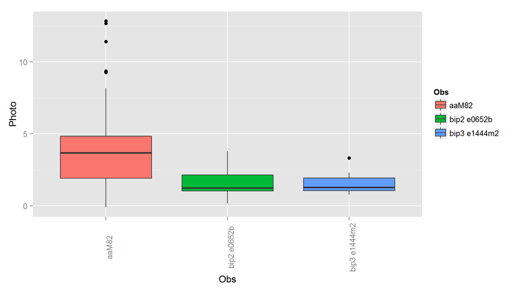

```r
## COMBINED BLOCKS PLOT
list=c("A")
testseta=droplevels(comb.data[comb.data$Block %in% list,])
testseta=droplevels(comb.data[grepl("M82|bip2|bip3",comb.data$Obs),])
# levels(testseta$Obs)
ggplot(testseta,aes(Obs,Photo,fill=Obs))+geom_boxplot()+theme(axis.text.x=element_text(angle=90))#+facet_wrap(~Weeks)
```

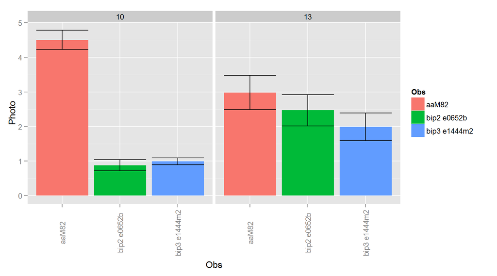

```r
ggplot(testseta,aes(Obs,Photo,fill=Obs))+stat_summary(fun.data=plot.summary,geom="bar")+stat_summary(fun.data=plot.summary,geom="errorbar")+facet_wrap(~ Weeks)+theme(axis.text.x  = element_text(angle=90, vjust=0.5))#+stat_smooth(method="lm",se=F)
```

```r
## MODELS
lma=lmer(Photo~Obs+VpdA+(1|Row)+(1|Col)+(1|Date)+(1|Weeks),data=testseta)
summary(lma)
```

```
## Linear mixed model fit by REML t-tests use Satterthwaite approximations
##   to degrees of freedom [merModLmerTest]
## Formula: Photo ~ Obs + VpdA + (1 | Row) + (1 | Col) + (1 | Date) + (1 |
##     Weeks)
##    Data: testseta
##
## REML criterion at convergence: 479.9
##
## Scaled residuals:
##     Min      1Q  Median      3Q     Max
## -1.7508 -0.5496 -0.0166  0.3593  3.3885
##
## Random effects:
##  Groups   Name        Variance Std.Dev.
##  Col      (Intercept) 1.0406   1.0201
##  Date     (Intercept) 0.0000   0.0000
##  Row      (Intercept) 0.1436   0.3789
##  Weeks    (Intercept) 0.1500   0.3873
##  Residual             3.5768   1.8913
## Number of obs: 111, groups:  Col, 56; Date, 6; Row, 5; Weeks, 2
##
## Fixed effects:
##                 Estimate Std. Error       df t value Pr(>|t|)
## (Intercept)       9.2480     0.9889  33.8700   9.352 6.55e-11 ***
## Obsbip2 e0652b   -3.4271     0.7140 105.5400  -4.800 5.26e-06 ***
## Obsbip3 e1444m2  -3.3220     0.8062 100.3700  -4.121 7.78e-05 ***
## VpdA             -1.5306     0.2564 100.1500  -5.969 3.63e-08 ***
## ---
## Signif. codes:  0 '***' 0.001 '**' 0.01 '*' 0.05 '.' 0.1 ' ' 1
##
## Correlation of Fixed Effects:
##             (Intr) O2e065 O3e144
## Obsbp2e0652 -0.305
## Obsb3e14442 -0.272  0.275
## VpdA        -0.910  0.249  0.225
```

```r
drop=drop1(lma)
drop
```

```
## Single term deletions
##
## Model:
## Photo ~ Obs + VpdA + (1 | Row) + (1 | Col) + (1 | Date) + (1 |
##     Weeks)
##        Df    AIC
## <none>    499.07
## Obs     2 522.85
## VpdA    1 522.02
```

```r
lma2=lmer(Photo~Obs+VpdA+(1|Row)+(1|Col)+(1|Weeks),data=testseta)
anova(lma,lma2)
```

```
## refitting model(s) with ML (instead of REML)
```

```
## Data: testseta
## Models:
## ..1: Photo ~ Obs + VpdA + (1 | Row) + (1 | Col) + (1 | Weeks)
## object: Photo ~ Obs + VpdA + (1 | Row) + (1 | Col) + (1 | Date) + (1 |
## object:     Weeks)
##        Df    AIC    BIC  logLik deviance Chisq Chi Df Pr(>Chisq)
## ..1     8 497.07 518.75 -240.53   481.07
## object  9 499.07 523.46 -240.53   481.07     0      1          1
```

```r
summary(lma2)
```

```
## Linear mixed model fit by REML t-tests use Satterthwaite approximations
##   to degrees of freedom [merModLmerTest]
## Formula: Photo ~ Obs + VpdA + (1 | Row) + (1 | Col) + (1 | Weeks)
##    Data: testseta
##
## REML criterion at convergence: 479.9
##
## Scaled residuals:
##     Min      1Q  Median      3Q     Max
## -1.7508 -0.5496 -0.0166  0.3593  3.3885
##
## Random effects:
##  Groups   Name        Variance Std.Dev.
##  Col      (Intercept) 1.0406   1.0201
##  Row      (Intercept) 0.1436   0.3789
##  Weeks    (Intercept) 0.1500   0.3873
##  Residual             3.5768   1.8913
## Number of obs: 111, groups:  Col, 56; Row, 5; Weeks, 2
##
## Fixed effects:
##                 Estimate Std. Error       df t value Pr(>|t|)
## (Intercept)       9.2480     0.9889  33.8700   9.352 6.55e-11 ***
## Obsbip2 e0652b   -3.4271     0.7140 105.5400  -4.800 5.26e-06 ***
## Obsbip3 e1444m2  -3.3220     0.8062 100.3700  -4.121 7.78e-05 ***
## VpdA             -1.5306     0.2564 100.1500  -5.969 3.63e-08 ***
## ---
## Signif. codes:  0 '***' 0.001 '**' 0.01 '*' 0.05 '.' 0.1 ' ' 1
##
## Correlation of Fixed Effects:
##             (Intr) O2e065 O3e144
## Obsbp2e0652 -0.305
## Obsb3e14442 -0.272  0.275
## VpdA        -0.910  0.249  0.225
```

```r
lma3=lmer(Photo~Obs+VpdA+(1|Col)+(1|Weeks),data=testseta)
anova(lma2,lma3)
```

```
## refitting model(s) with ML (instead of REML)
```

```
## Data: testseta
## Models:
## ..1: Photo ~ Obs + VpdA + (1 | Col) + (1 | Weeks)
## object: Photo ~ Obs + VpdA + (1 | Row) + (1 | Col) + (1 | Weeks)
##        Df    AIC    BIC  logLik deviance  Chisq Chi Df Pr(>Chisq)
## ..1     7 495.61 514.57 -240.80   481.61
## object  8 497.07 518.75 -240.53   481.07 0.5358      1     0.4642
```

```r
summary(lma3)
```

```
## Linear mixed model fit by REML t-tests use Satterthwaite approximations
##   to degrees of freedom [merModLmerTest]
## Formula: Photo ~ Obs + VpdA + (1 | Col) + (1 | Weeks)
##    Data: testseta
##
## REML criterion at convergence: 480.6
##
## Scaled residuals:
##     Min      1Q  Median      3Q     Max
## -1.5843 -0.5389 -0.0277  0.3441  3.4650
##
## Random effects:
##  Groups   Name        Variance Std.Dev.
##  Col      (Intercept) 1.0561   1.0276
##  Weeks    (Intercept) 0.1577   0.3971
##  Residual             3.6733   1.9166
## Number of obs: 111, groups:  Col, 56; Weeks, 2
##
## Fixed effects:
##                 Estimate Std. Error       df t value Pr(>|t|)
## (Intercept)       9.1092     0.9727  39.2700   9.365 1.49e-11 ***
## Obsbip2 e0652b   -3.3394     0.7181 106.0400  -4.650 9.61e-06 ***
## Obsbip3 e1444m2  -3.2215     0.8126 101.4900  -3.964 0.000137 ***
## VpdA             -1.5057     0.2562  99.7400  -5.876 5.58e-08 ***
## ---
## Signif. codes:  0 '***' 0.001 '**' 0.01 '*' 0.05 '.' 0.1 ' ' 1
##
## Correlation of Fixed Effects:
##             (Intr) O2e065 O3e144
## Obsbp2e0652 -0.306
## Obsb3e14442 -0.276  0.267
## VpdA        -0.921  0.247  0.227
```

```r
lma4=lmer(Photo~Obs+VpdA+(1|Col),data=testseta)
anova(lma3,lma4)
```

```
## refitting model(s) with ML (instead of REML)
```

```
## Data: testseta
## Models:
## ..1: Photo ~ Obs + VpdA + (1 | Col)
## object: Photo ~ Obs + VpdA + (1 | Col) + (1 | Weeks)
##        Df    AIC    BIC  logLik deviance  Chisq Chi Df Pr(>Chisq)
## ..1     6 493.95 510.21 -240.98   481.95
## object  7 495.61 514.57 -240.80   481.61 0.3487      1     0.5549
```

```r
summary(lma4)
```

```
## Linear mixed model fit by REML t-tests use Satterthwaite approximations
##   to degrees of freedom [merModLmerTest]
## Formula: Photo ~ Obs + VpdA + (1 | Col)
##    Data: testseta
##
## REML criterion at convergence: 481.5
##
## Scaled residuals:
##     Min      1Q  Median      3Q     Max
## -1.6733 -0.5303 -0.0028  0.3716  3.5390
##
## Random effects:
##  Groups   Name        Variance Std.Dev.
##  Col      (Intercept) 1.078    1.038
##  Residual             3.743    1.935
## Number of obs: 111, groups:  Col, 56
##
## Fixed effects:
##                 Estimate Std. Error       df t value Pr(>|t|)
## (Intercept)       9.3130     0.9294 102.1700  10.020  < 2e-16 ***
## Obsbip2 e0652b   -3.3986     0.7239 106.7300  -4.695 7.96e-06 ***
## Obsbip3 e1444m2  -3.3567     0.8149 101.7800  -4.119 7.76e-05 ***
## VpdA             -1.5511     0.2568  99.4000  -6.041 2.67e-08 ***
## ---
## Signif. codes:  0 '***' 0.001 '**' 0.01 '*' 0.05 '.' 0.1 ' ' 1
##
## Correlation of Fixed Effects:
##             (Intr) O2e065 O3e144
## Obsbp2e0652 -0.315
## Obsb3e14442 -0.276  0.263
## VpdA        -0.962  0.243  0.216
```

```r
##
```

lma4 is the simpilest model. Predictions run from it.

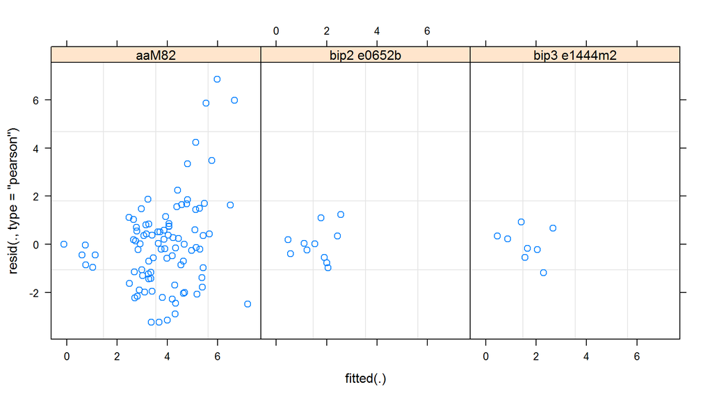

```r
## PLOTS
plot(lma4,resid(.,type="pearson")~fitted(.)|Obs)
```

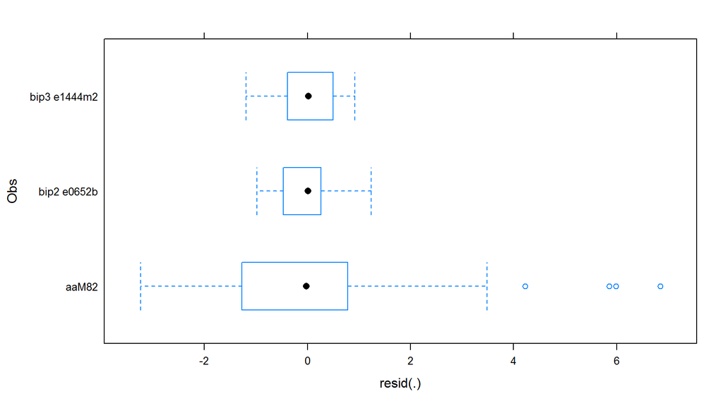

```r
plot(lma4, Obs~resid(.))
```

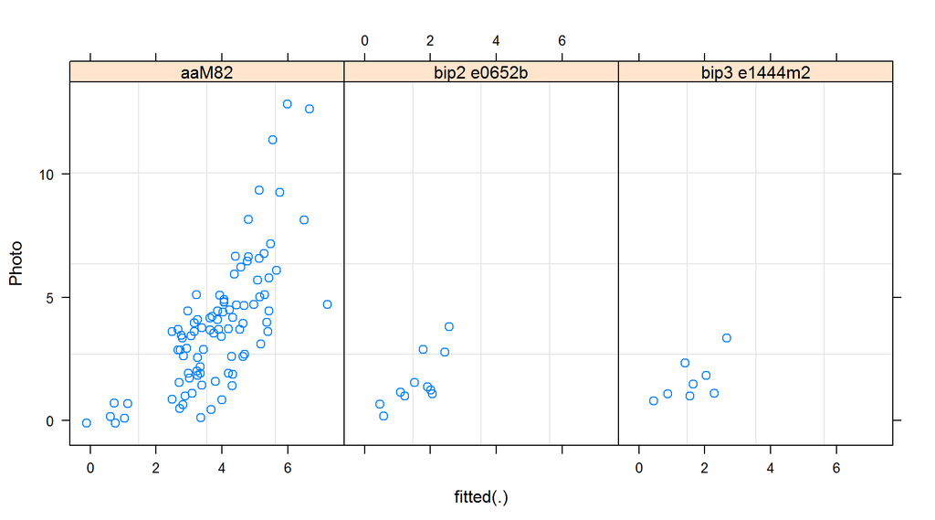

```r
plot(lma4, Photo~fitted(.)|Obs)
```

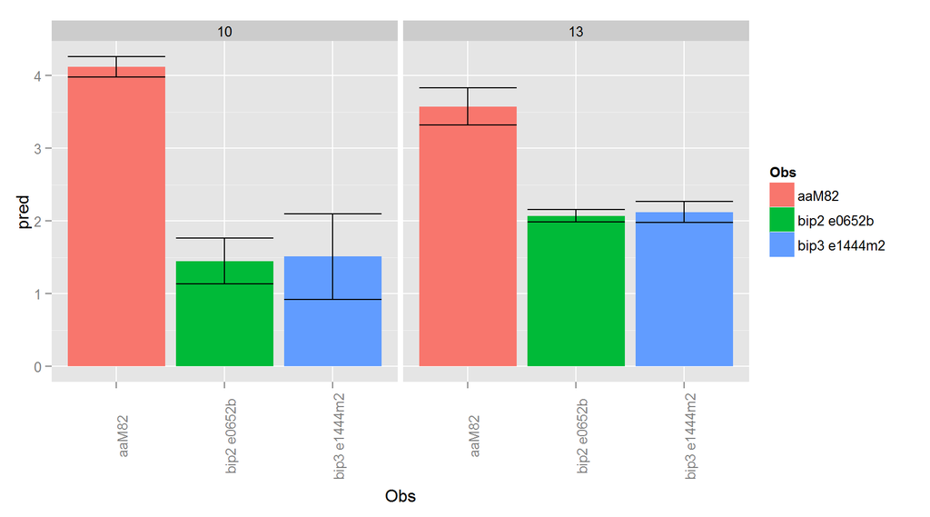

```r
testseta$pred=predict(lma4,re.form=NA)
ggplot(testseta,aes(Obs,pred,fill=Obs))+stat_summary(fun.data=plot.summary,geom="bar")+stat_summary(fun.data=plot.summary,geom="errorbar")+theme(axis.text.x=element_text(angle=90))+facet_wrap(~Weeks)
```

```r
##

# ## RESIDUALS
# lmtesta=lm(Photo~VpdA,data=testseta)
# summary(lmtesta)
# testseta$resid=residuals(lmtesta)
#
# ggplot(testseta,aes(Obs,resid,colour=Obs))+stat_summary(fun.data=plot.summary,geom="point",size=3)+stat_summary(fun.data=plot.summary,geom="errorbar")+theme(axis.text.x=element_text(angle=90))+facet_wrap(~Weeks)
# # Combined residuals.
# ggplot(testseta,aes(Obs,resid,colour=Obs))+stat_summary(fun.data=plot.summary,geom="point",size=3)+stat_summary(fun.data=plot.summary,geom="errorbar")+theme(axis.text.x=element_text(angle=90))
#
# lma6=lmer(resid~Obs+VpdA+(1|Row)+(1|Col)+(1|Date)+(1|Weeks),data=testseta)
# summary(lma6)
#
# lma7=lmer(resid~Obs+VpdA+(1|Row)+(1|Col)+(1|Weeks),data=testseta)
# anova(lma6,lma7)
# summary(lma7)
#
# lma8=lmer(resid~Obs+VpdA+(1|Col),data=testseta)
# anova(lma7,lma8)
# summary(lma8)
# ##
```

======================================  
**BLOCK A PHOTOSYNTHESIS MODEL entire-2922 bip-3765 AC**

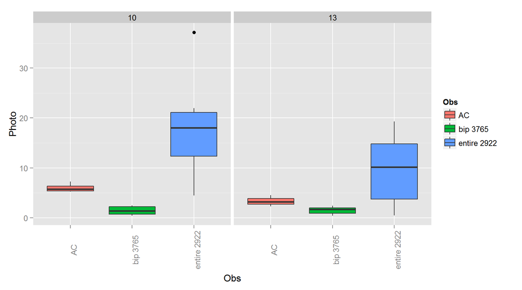

```r
## COMBINED BLOCKS PLOT
list=c("A")
testset3765=droplevels(comb.data[comb.data$Block %in% list,])
testset3765=droplevels(comb.data[grepl("bip 3765|AC|entire 2922",comb.data$Obs),])
# levels(testset3765$Obs)
ggplot(testset3765,aes(Obs,Photo,fill=Obs))+geom_boxplot()+theme(axis.text.x=element_text(angle=90))+facet_wrap(~Weeks)
```

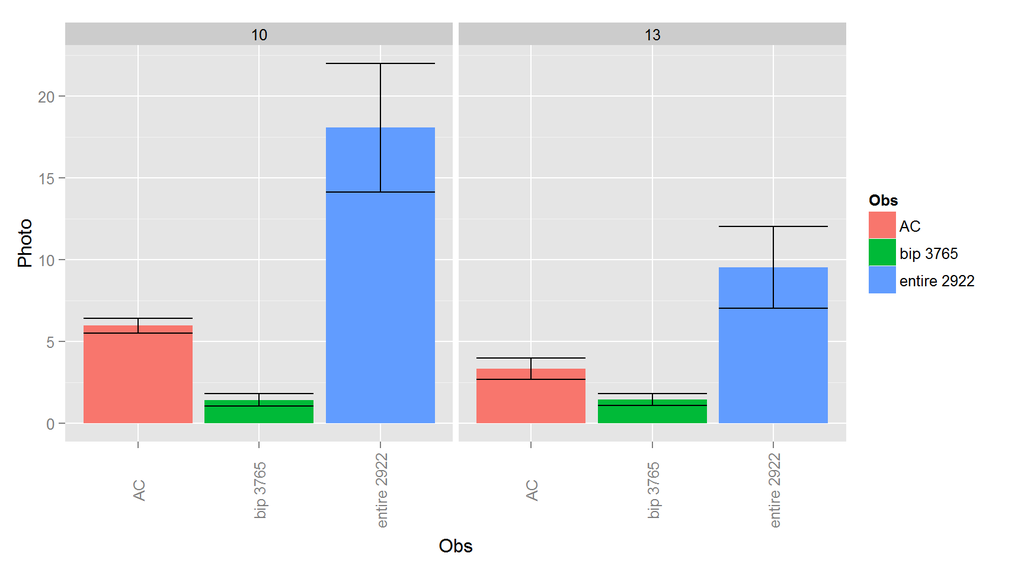

```r
ggplot(testset3765,aes(Obs,Photo,fill=Obs))+stat_summary(fun.data=plot.summary,geom="bar")+stat_summary(fun.data=plot.summary,geom="errorbar")+facet_wrap(~ Weeks)+theme(axis.text.x  = element_text(angle=90, vjust=0.5))#+stat_smooth(method="lm",se=F)
```

```r
## MODELS
lm3765=lmer(Photo~Obs+VpdA+(1|Row)+(1|Col)+(1|Date)+(1|Weeks),data=testset3765)
summary(lm3765)
```

```
## Linear mixed model fit by REML t-tests use Satterthwaite approximations
##   to degrees of freedom [merModLmerTest]
## Formula: Photo ~ Obs + VpdA + (1 | Row) + (1 | Col) + (1 | Date) + (1 |
##     Weeks)
##    Data: testset3765
##
## REML criterion at convergence: 188.3
##
## Scaled residuals:
##      Min       1Q   Median       3Q      Max
## -1.75707 -0.36058  0.05394  0.39676  2.99934
##
## Random effects:
##  Groups   Name        Variance Std.Dev.
##  Col      (Intercept)  1.899   1.378
##  Date     (Intercept)  0.000   0.000
##  Row      (Intercept) 32.575   5.707
##  Weeks    (Intercept)  0.000   0.000
##  Residual             20.360   4.512
## Number of obs: 33, groups:  Col, 14; Date, 5; Row, 5; Weeks, 2
##
## Fixed effects:
##                Estimate Std. Error       df t value Pr(>|t|)
## (Intercept)     31.8450     9.9172  28.8830   3.211  0.00324 **
## Obsbip 3765      0.6174     2.5812  19.0300   0.239  0.81351
## Obsentire 2922  12.0868     2.3763  22.7540   5.086 3.88e-05 ***
## VpdA           -11.1139     3.6759  27.9340  -3.023  0.00531 **
## ---
## Signif. codes:  0 '***' 0.001 '**' 0.01 '*' 0.05 '.' 0.1 ' ' 1
##
## Correlation of Fixed Effects:
##             (Intr) Ob3765 Ob2922
## Obsbip 3765  0.203
## Obsentr2922 -0.172  0.603
## VpdA        -0.946 -0.366  0.011
```

```r
drop1(lm3765)
```

```
## Single term deletions
##
## Model:
## Photo ~ Obs + VpdA + (1 | Row) + (1 | Col) + (1 | Date) + (1 |
##     Weeks)
##        Df    AIC
## <none>    220.84
## Obs     2 240.74
## VpdA    1 226.14
```

```r
lm37652=lmer(Photo~Obs+VpdA+(1|Row)+(1|Col),data=testset3765)
anova(lm3765,lm37652)
```

```
## refitting model(s) with ML (instead of REML)
```

```
## Data: testset3765
## Models:
## ..1: Photo ~ Obs + VpdA + (1 | Row) + (1 | Col)
## object: Photo ~ Obs + VpdA + (1 | Row) + (1 | Col) + (1 | Date) + (1 |
## object:     Weeks)
##        Df    AIC    BIC  logLik deviance Chisq Chi Df Pr(>Chisq)
## ..1     7 216.84 227.32 -101.42   202.84
## object  9 220.84 234.31 -101.42   202.84     0      2          1
```

```r
summary(lm37652)
```

```
## Linear mixed model fit by REML t-tests use Satterthwaite approximations
##   to degrees of freedom [merModLmerTest]
## Formula: Photo ~ Obs + VpdA + (1 | Row) + (1 | Col)
##    Data: testset3765
##
## REML criterion at convergence: 188.3
##
## Scaled residuals:
##      Min       1Q   Median       3Q      Max
## -1.75707 -0.36058  0.05394  0.39676  2.99934
##
## Random effects:
##  Groups   Name        Variance Std.Dev.
##  Col      (Intercept)  1.899   1.378
##  Row      (Intercept) 32.575   5.707
##  Residual             20.360   4.512
## Number of obs: 33, groups:  Col, 14; Row, 5
##
## Fixed effects:
##                Estimate Std. Error       df t value Pr(>|t|)
## (Intercept)     31.8450     9.9172  28.8830   3.211  0.00324 **
## Obsbip 3765      0.6174     2.5812  19.0300   0.239  0.81351
## Obsentire 2922  12.0868     2.3763  22.7540   5.086 3.88e-05 ***
## VpdA           -11.1139     3.6759  27.9340  -3.023  0.00531 **
## ---
## Signif. codes:  0 '***' 0.001 '**' 0.01 '*' 0.05 '.' 0.1 ' ' 1
##
## Correlation of Fixed Effects:
##             (Intr) Ob3765 Ob2922
## Obsbip 3765  0.203
## Obsentr2922 -0.172  0.603
## VpdA        -0.946 -0.366  0.011
```

```r
lm37653=lmer(Photo~Obs+VpdA+(1|Row),data=testset3765)
anova(lm37652,lm37653)
```

```
## refitting model(s) with ML (instead of REML)
```

```
## Data: testset3765
## Models:
## ..1: Photo ~ Obs + VpdA + (1 | Row)
## object: Photo ~ Obs + VpdA + (1 | Row) + (1 | Col)
##        Df    AIC    BIC  logLik deviance  Chisq Chi Df Pr(>Chisq)
## ..1     6 214.89 223.87 -101.44   202.89
## object  7 216.84 227.32 -101.42   202.84 0.0421      1     0.8374
```

```r
summary(lm37653)
```

```
## Linear mixed model fit by REML t-tests use Satterthwaite approximations
##   to degrees of freedom [merModLmerTest]
## Formula: Photo ~ Obs + VpdA + (1 | Row)
##    Data: testset3765
##
## REML criterion at convergence: 188.4
##
## Scaled residuals:
##      Min       1Q   Median       3Q      Max
## -1.77480 -0.49027  0.03444  0.49709  3.08533
##
## Random effects:
##  Groups   Name        Variance Std.Dev.
##  Row      (Intercept) 30.33    5.508
##  Residual             22.30    4.722
## Number of obs: 33, groups:  Row, 5
##
## Fixed effects:
##                Estimate Std. Error      df t value Pr(>|t|)
## (Intercept)      31.065      9.908  28.943   3.135  0.00392 **
## Obsbip 3765       0.795      2.510  25.054   0.317  0.75404
## Obsentire 2922   12.054      2.337  25.675   5.157  2.3e-05 ***
## VpdA            -10.876      3.690  28.136  -2.948  0.00637 **
## ---
## Signif. codes:  0 '***' 0.001 '**' 0.01 '*' 0.05 '.' 0.1 ' ' 1
##
## Correlation of Fixed Effects:
##             (Intr) Ob3765 Ob2922
## Obsbip 3765  0.220
## Obsentr2922 -0.172  0.584
## VpdA        -0.949 -0.377  0.015
```

```r
##
```

Not shown here but bip 3765 is sig. different if run without entire 2922 included. Included both because of same parent line.

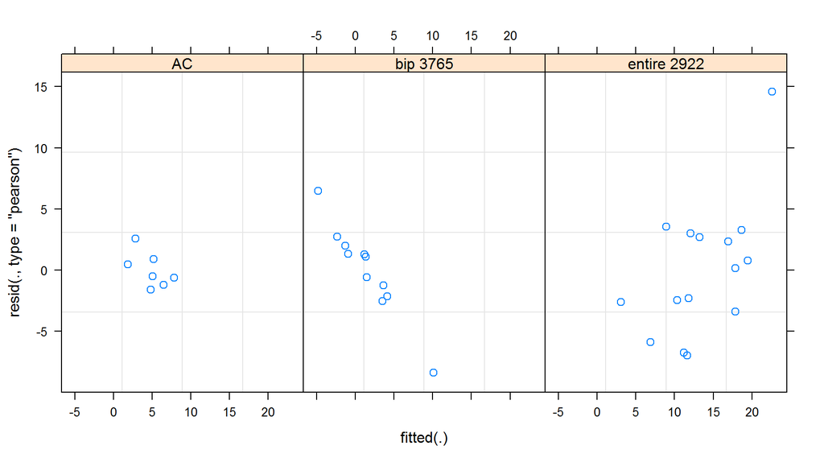

```r
## PLOTS
plot(lm37653,resid(.,type="pearson")~fitted(.)|Obs)#,id=0.05,adj=-0.3)
```

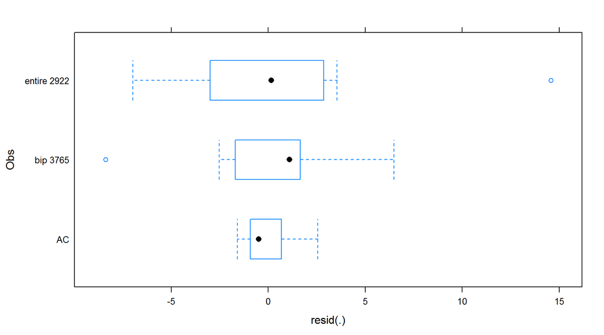

```r
plot(lm37653, Obs~resid(.))
```

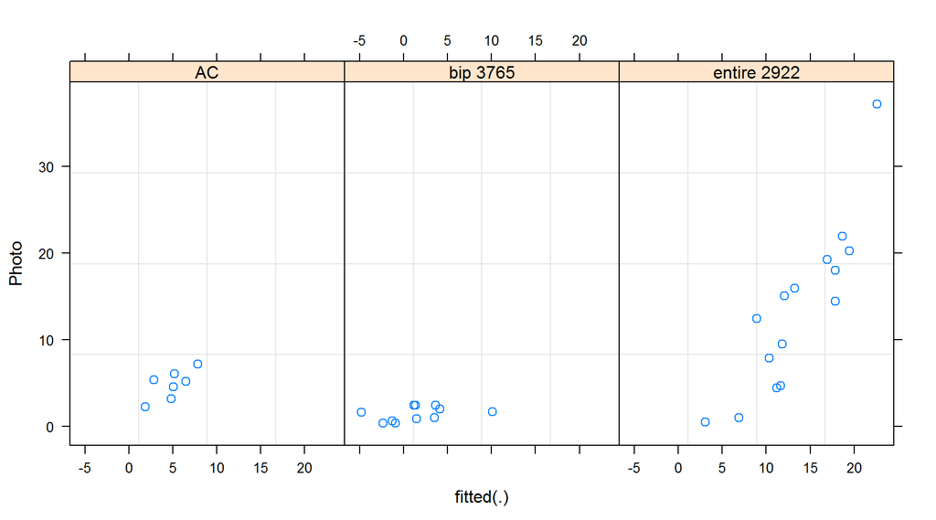

```r
plot(lm37653, Photo~fitted(.)|Obs)
```

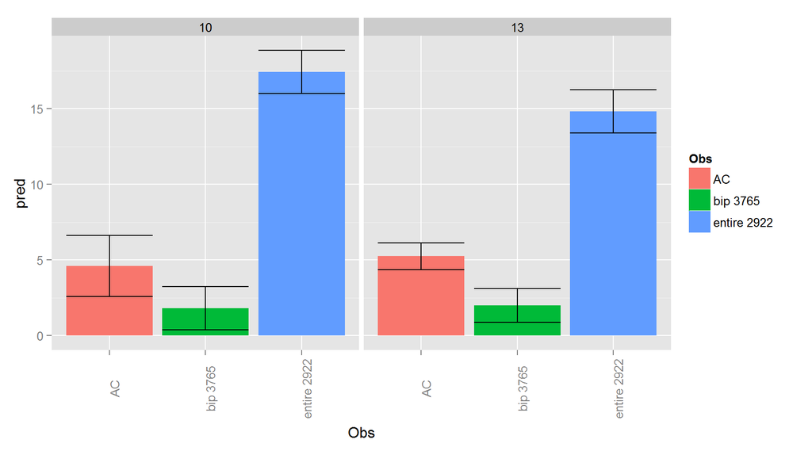

```r
testset3765$pred=predict(lm37653,re.form=NA)
ggplot(testset3765,aes(Obs,pred,fill=Obs))+stat_summary(fun.data=plot.summary,geom="bar")+stat_summary(fun.data=plot.summary,geom="errorbar")+theme(axis.text.x=element_text(angle=90))+facet_wrap(~Weeks)
```

```r
##
```

======================================  
**BLOCK A PHOTOSYNTHESIS MODEL entire 3-616 VFNT**

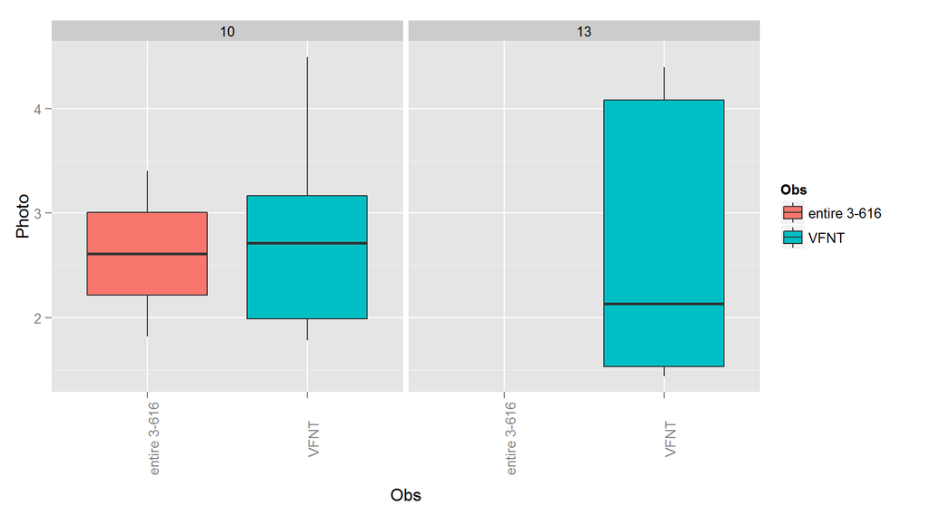

```r
## COMBINED BLOCKS PLOT
list=c("A")
testset.entire=droplevels(comb.data[comb.data$Block %in% list,])
testset.entire=droplevels(comb.data[grepl("entire 3-616|VFNT",comb.data$Obs),])
# levels(testset3765$Obs)
ggplot(testset.entire,aes(Obs,Photo,fill=Obs))+geom_boxplot()+theme(axis.text.x=element_text(angle=90))+facet_wrap(~Weeks)
```

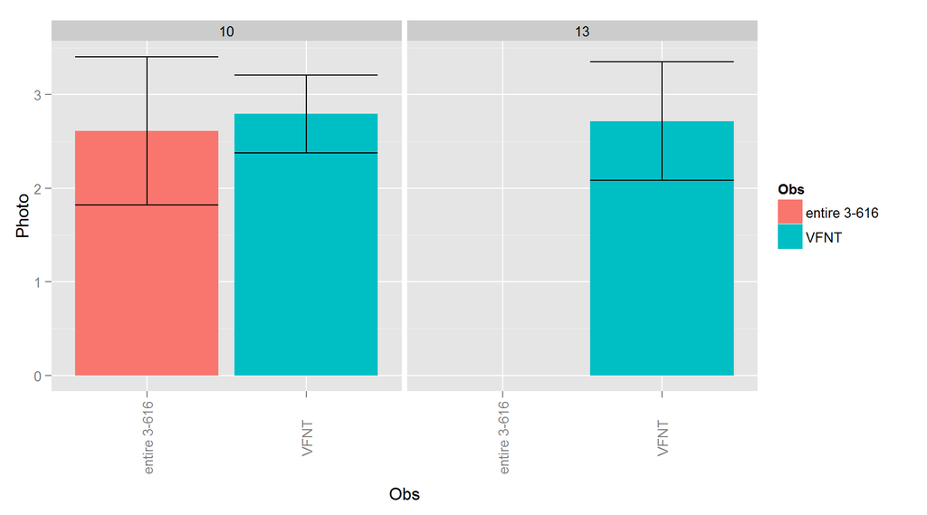

```r
ggplot(testset.entire,aes(Obs,Photo,fill=Obs))+stat_summary(fun.data=plot.summary,geom="bar")+stat_summary(fun.data=plot.summary,geom="errorbar")+facet_wrap(~ Weeks)+theme(axis.text.x  = element_text(angle=90, vjust=0.5))#+stat_smooth(method="lm",se=F)
```

==========================================